# Figure 3d

PC3 stable line pollII ChIP

Jason T. Serviss

31/01/2017

#### *Introduction*

miR34a asRNA over-expression was shown to increase the expression levels of miR34a. We investigated if this increase of miR34a was due to increased levels of transcription at the miR34a promoter.

#### *Methods*

*Cell culture, QPCR, and ChIP*

All cell lines were cultured at 5% CO2 and 37° C with Skov3 and PC3 cells in RPMI (Hyclone) and 2 mM L-glutamine and Saos2 cells cultured in DMEM high modified (Hyclone). All growth mediums were supplemented with 10% heat-inactivated FBS and 50 μg/ml of streptomycin and 50 μg/ml of penicillin. Cells were plated at 2-3x10^6 cells in a 15cm dish and incubated overnight. Cells were cross-linked in 1% formaldehyde, quenched in glycine (0.125M), resuspended in cell lysis buffer (5mM PIPES, 85mM KCL, 0.5% NP40, protease inhibitor), and sonicated (Bioruptor Sonicator Diagenode) in nucleus lysis buffer (50mM TRIS-HCL pH 8.0, 10mM EDTA, 1% SDS, protease inhibitor). The samples were incubated overnight at 4 °C with the appropriate antibody. Salmon sperm DNA/Protein A–agarose (Upstate/Millipore) was used to pull down the antibody. DNA was eluted in elution buffer (1% SDS, 100 mM NaHCO3), followed by reverse cross-linking, RNase-A and protease-K treatment. The DNA was eluted by using a Qiagen PCR purification kit. The following antibodies were used (4 μg/sample): phospho-polymerase II (abcam: ab5095). QPCR was carried out using KAPA 2G SYBRGreen (Kapa Biosystems) using the Applied Biosystems 7900HT machine with the cycling conditions: 95 °C for 3 min, 95 °C for 3 s, 60 °C for 30 s.

*Analysis*

*Primers*

```r
primers <- data.frame(
    name=c(
        "miR34aChIP F1",
        "miR34aChIP R1"
    ),
    sequence=c(
       "AAA GTT TGC AAA GAA GGA GGC GGG",
       "AGG GAA GAA AGA ACT AGC CGA GCA"
    )
)
primers
```

| name | sequence |
| --- | --- |
| miR34aChIP F1 | AAA GTT TGC AAA GAA GGA GGC GGG |
| miR34aChIP R1 | AGG GAA GAA AGA ACT AGC CGA GCA |

#### *Results*

```r
data <- getData("Figure 3d")

#calculate means of technical replicates
data <- mutate(data, techMean = rowMeans(select(data, Quantity1, Quantity2)))

#calculate fraction of input
.fractionOfInput <- function(data, techMean, Biological.Replicate, condition) {
  bool1 <- data$`Biological Replicate` == Biological.Replicate
  bool2 <- data$condition == condition
  bool3 <- data$sample == "input"
  bool <- bool1 & bool2 & bool3
  techMean / pull(data, techMean)[bool]
}

data <- data %>%
  group_by(`Biological Replicate`, condition, sample) %>%
  mutate(fractionInput = .fractionOfInput(data, techMean, `Biological Replicate`, condition)) %>%
  ungroup() %>%
  filter(sample != "input")

#calculate fold over mock
.foldOverControl <- function(data, fractionInput, Biological.Replicate) {
  bool1 <- data$`Biological Replicate` == 3
  bool2 <- data$condition == "mock"
  bool <- bool1 & bool2
  fractionInput / pull(data, fractionInput)[bool]
}

data <- data %>%
  mutate(
    foldOverControl = .foldOverControl(data, fractionInput, `Biological Replicate`),
    logfoldOverControl= log2(foldOverControl)
  ) %>%
  ungroup()

#calculate stats
stats <- data %>%
  group_by(condition) %>%
  summarize(
    n = n(),
    mean = mean(logfoldOverControl),
    CI95l =t.test(logfoldOverControl)$conf.int[1],
    CI95h =t.test(logfoldOverControl)$conf.int[2],
    pValue = t.test(logfoldOverControl, mu = 0)$p.value
  ) %>%
  pFormat(.) %>%
  mutate(pFormat = case_when(
    condition == "mock" ~ "",
    TRUE ~ pFormat
  ))
```

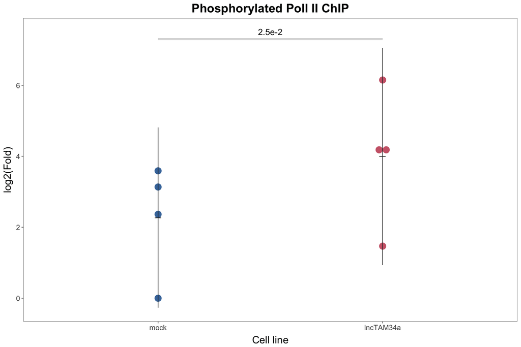

```r
p <- ggplot(data = NULL) +
  geom_dotplot(
    data = data,
    aes(
      x = condition,
      y = logfoldOverControl,
      fill = condition
    ),
    binwidth = 1/10,
    #alpha = 0.5,
    colour = NA,
    position = position_dodge(width = 0.9),
    binaxis='y',
    stackdir='center',
    dotsize = 2,
    show.legend = TRUE
  ) +
  scale_y_continuous("log2(Fold)") +
  labs(
    x = "Cell line",
    y = "log2(Fold polII enrichment)",
    title = "Phosphorylated Poll II ChIP"
  ) +
  guides(fill = FALSE)

markdown <- p +
    geom_linerange(
    data = stats,
    aes(x = condition, ymin = CI95l, ymax = CI95h),
    colour = "gray20",
    show.legend = FALSE
  ) +
  geom_point(
    data = stats,
    aes(x = condition, y = mean),
    colour = "gray20",
    shape = 95,
    size = 6,
    show.legend = FALSE
  ) +
  geom_segment(
    data = filter(stats, condition == "lncTAM34a"),
    aes(x = 1, y = CI95h + 0.25, xend = 2, yend = CI95h + 0.25),
    colour = "grey43"
  ) +
  geom_label(
    data = stats,
    aes(x = 1.5, y = CI95h + 0.45, label = pFormat),
    label.size = 0,
    label.padding = unit(0.01, "lines"),
    show.legend = FALSE,
    fill = "white",
    size = 5,
    family = "Arial Unicode MS"
  )

plotRmarkdown(markdown)
```

```r
pdf <- p +
    geom_linerange(
    data = stats,
    aes(x = condition, ymin = CI95l, ymax = CI95h),
    colour = "grey30",
    size = 0.3,
    show.legend = FALSE
  ) +
  geom_point(
    data = stats,
    aes(x = condition, y = mean),
    colour = "grey30",
    shape = 95,
    size = 4,
    show.legend = FALSE
  ) +
  geom_segment(
    data = filter(stats, condition == "lncTAM34a"),
    aes(x = 1, y = CI95h + 0.25, xend = 2, yend = CI95h + 0.25),
    colour = "grey30",
    size = 0.3
  ) +
  geom_label(
    data = stats,
    aes(x = 1.5, y = CI95h + 0.45, label = pFormat),
    label.size = 0,
    label.padding = unit(0.01, "lines"),
    show.legend = FALSE,
    fill = "white",
    colour = "grey30",
    size = 2.5,
    family = "Arial Unicode MS"
  )

figure <- plotPDF(pdf)

# path <- file.path("~/GitHub/miR34a_asRNA_project/inst", fileMap(type = "pdf")["Figure 3d"][[1]])
# ggsave(
#   plot = figure,
#   filename = path,
#   device = cairo_pdf,
#   height = 60,
#   width = 43,
#   units = "mm",
#   dpi = 10000000
# )
```

Phosphorylated Poll II ChIP in miR34a asRNA over-expressing PC3 stable cell lines compared to their respective mock control. The points represent the values obtained from each independant experiment (n = 4). 95% confidence interval (vertical black lines), mean (horizontal black lines), and p-values are shown with the horizontal line under the p-value indicating the comparison that was tested.

#### *Conclusion*

Phosphorylated pol-II was increased at the miR34a promoter in miR34a asRNA over-expressing cell lines indicating that the regulation of miR34a by miR34a asRNA is transcriptional.